[figure not shown]

Lagos Business School · Executive Education · Turning Data into Business Growth

# Seeing, forecasting, segmenting

Day 3 · See it, model it · Wednesday 14 October 2026

Prof. Bongo Adi · Lagos Business School

## Today

The densest day of the week — and the one most likely to produce a result that is both impressive and wrong.

You will build a churn model that scores 0.98, and then discover why that number should have frightened you rather than pleased you.

## 3.1 · What is odd here?

09:15 — 10:15 · Exploratory data analysis, properly

## The question is not “what is the average?”

“What is odd here?”

Confirmatory analysis asks *is this true?*, which is a good question — but it only ever inspects the thing you already suspected.

An assistant will produce a mean, a median and a chart of anything you point it at, in seconds, **without ever having looked at the shape of the data.** It has no capacity to be surprised.

You do, and surprise is now the scarce input.

## Five things, in this order

1. **The shape of the file.** How many rows, over what period, at what grain, with how much missing. `SUMMARIZE` answers all four.
2. **The calendar.** Count the periods before you compare them.
3. **The distribution**, rather than the average — because the average is a summary of a shape you have not yet seen.
4. **Missingness, as a pattern.** Not “how much is missing?” but “what do the missing rows have in common?”
5. **Time, plotted.** The series itself, not a summary of it.

Ask for “revenue by year” and you get three bars. 2026 is about 70% below 2025 and the deck writes itself.

**2026 has thirteen weeks in it.**

## What “grain” and “missing” are doing in that list

**Grain** is the answer to one question: *what does a single row of this table represent?* One row per customer. One row per order line. One row per depot, per SKU, per week.

**Missing** is not one thing. A blank cell can mean *we sold none*, or *we do not know*, or *this question did not apply* — and only one of those is safely treated as a zero.

Neither idea requires any statistics, and between them they account for a large share of the wrong numbers that reach board papers.

## The mean sits where almost no week is

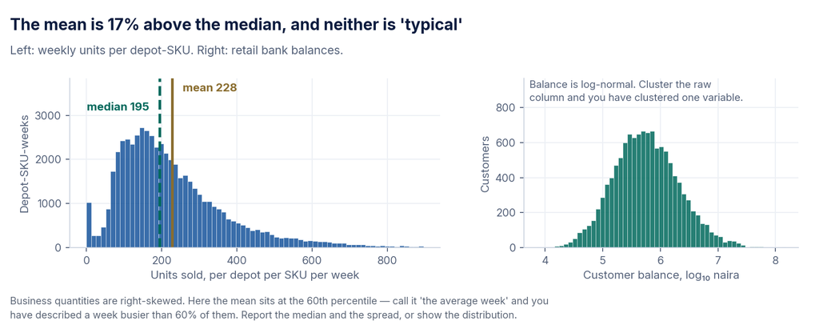

## Plot the series before you model it

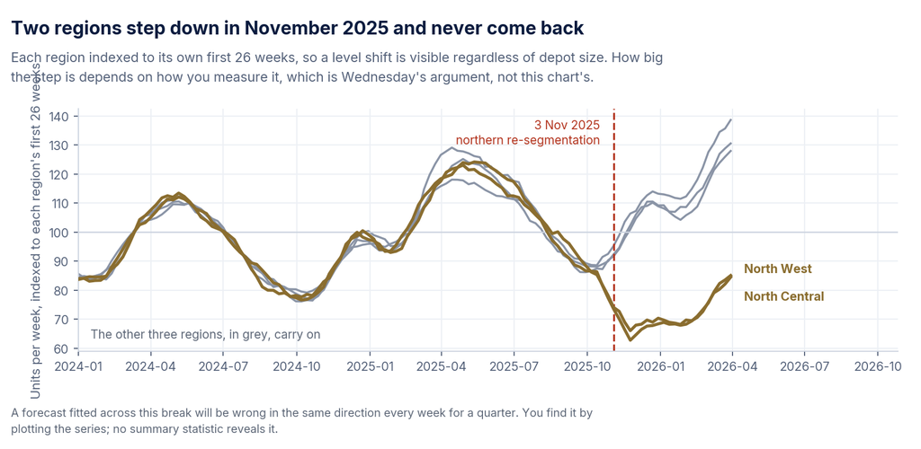

## Now in your sector · 3.1

Energy & extractives

Plot before you average. A pipeline shut-in is a break, not a bad month. A lab outlier may be the method, not the crude.

Data: energy_production_daily.csv, energy_lab_qc.csv

Pensions & public sector

Remittances spike after enforcement drives and at year end. Before you call a trend, ask whether the most recent months are complete.

Data: pension_remittances.csv

Financial services

Month-end spikes and dormant accounts.

Data: bank_customers.csv

Commercial & customer

Festive peaks; stockouts that look like weak demand.

Data: fmcg_sell_out.csv

## 3.2 · Charts that survive a board room

10:45 — 11:45 · A chart is an argument, not a display

## Write the claim first. Then choose the form.

| The claim | The form |
| --- | --- |
| X is bigger than Y | Sorted bar, one colour, difference annotated |
| X is changing over time | Line. Never a bar |
| X is changing faster than Y | Indexed line, both starting at 100 |
| X is spread more widely than you think | The distribution — or the points |
| X is uncertain by this much | Line with a shaded interval |
| Most of X comes from a few Y | Pareto: sorted bars, cumulative line |

**The title of the chart is the claim.** Not “Revenue by region”, but *“North Central has lost a quarter of its volume since November.”*

## Every chart is three decisions

1. **Data** — which rows are in the picture at all.
2. **Aesthetics** — which variable is mapped to position, to colour, to size, to shape.
3. **Geometry** — what marks actually get drawn: points, lines, bars, areas.

Change the geometry and keep the other two, and you have a different chart of the same data. That is the whole of the *grammar of graphics*, and it is why “which chart should I use?” is a tractable question rather than a matter of taste.

## Ban the bar chart of means

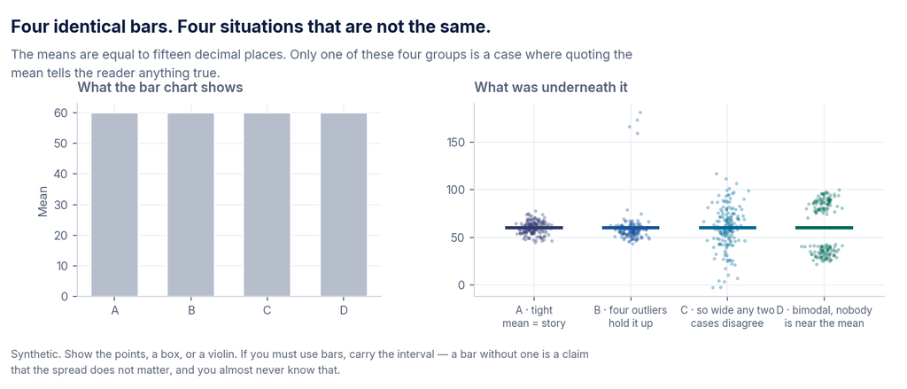

Left: four identical grey bars, all at 60. Right: the underlying points for each group, showing a tight cluster, a group held up by four extreme outliers, a very wide spread, and a bimodal split with nothing near the mean.

## Design for two seconds

Your audience gets about two seconds with a chart before they either understand it or stop trying, so design for two seconds: sorted rather than alphabetical, labelled directly rather than through a legend, one colour unless colour carries meaning, the claim in the title, and the comparison you want made sitting physically adjacent on the page.

Compare along a **common baseline**.

Eyes compare lengths from a shared starting point accurately, and compare angles, areas and colour intensity badly. That single fact is why sorted bars beat pie charts, why stacked bars stop working beyond two or three segments, and why “which is bigger?” should almost never be answered with a treemap.

## Colour, chosen once

Pick a palette once and use it everywhere, so that the same category is the same colour in every chart in the pack. Across a fifty-page board document that consistency does more for comprehension than any individual chart improvement.

Three rules that matter more than taste:

1. **Check it in greyscale**, because somebody will print it.
2. **Never encode meaning in red-versus-green alone.** Red-green colour vision deficiency affects several per cent of men, so in a large cohort it is likely to be somebody in the room. Use position, shape or a label as well.
3. **Reserve one loud colour** for the thing you are arguing about. Everything else grey.

## Now in your sector · 3.2

Energy & extractives

A deferment waterfall (planned vs unplanned) for the management committee; a control chart, not a bar of means, for the lab.

Data: energy_production_daily.csv

Pensions & public sector

Compliance by sector as small multiples, and an exception list rather than a map of counts by state.

Data: pension_remittances.csv

Financial services

PAR by branch as a dot plot with the distribution shown.

Data: bank_customers.csv

Commercial & customer

Churn by tenure cohort.

Data: bank_customers.csv

## 3.3 · Forecasting with intervals

11:45 — 12:45 · Trend, season, break, backtest

## A forecast without an interval is a wish

A point estimate of ₦2.4bn tells a planner nothing about how much safety stock to hold.

The same forecast with an 80% interval of ₦1.9bn to ₦2.9bn tells them everything they need: the downside they must be able to survive, the upside they should be able to serve, and the width of your own uncertainty.

The interval is the forecast. The central line is a convenience.

## The interval is the forecast

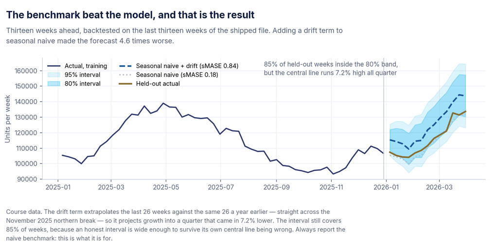

Weekly units with a thirteen-week backtest. A dashed forecast line runs consistently above the gold actual line; a dotted plain seasonal-naive line tracks the actual closely. Widening blue interval bands cover the actual throughout.

## Four components, in order

Before fitting anything, take the series apart:

**Level** — where it sits. **Trend** — where it is going. **Season** — the repeating annual, monthly or weekly pattern. **Remainder** — everything left over.

The remainder is the panel to read. Structure in it — a step, a run of same-signed errors, variance that grows — means the model has missed something real. Random scatter means it has captured what there was to capture.

## Always fit the naive benchmark

`NAIVE` says next week equals this week. `SNAIVE` says this week equals the same week last year.

Neither of those took any skill, which is exactly what makes them useful. If a sophisticated model cannot beat both of them on data it has never seen, **it is not earning its licence fee** — and you found that out in ten seconds rather than in a year.

Report the benchmark alongside your model, always. It is the single most credibility-building line in a forecasting presentation, because it shows the audience that you tried to prove yourself wrong.

## Read MASE, not MAPE

**MAPE** — mean absolute percentage error — is the one everybody quotes. It is undefined when the actual is zero, it explodes when the actual is small, and it penalises over-forecasting and under-forecasting by different amounts. For a business with stockouts and small SKUs, both of those problems are live rather than theoretical.

**MASE** scales your error by the error the naive rule makes, which is what makes it comparable across series of wildly different sizes.

Below 1, you beat naive. Above 1, you did not.

## Backtesting is the only evidence that counts

How well a model fits data it has already seen tells you almost nothing — it is marking its own homework. What you need is its performance on periods it has never seen, repeatedly.

**One holdout is a sample of size one.** Rolling the origin forward — refit at many cut-off points, forecast the same horizon from each, and average the error across all of them — gives the same comparison at every point in your history.

It is the difference between *“our model beat naive”* and *“our model beats naive.”*

## The break, and the three legitimate answers

1. **Refit on the post-break period only.** Fewer observations, an honest level. Say in the note how many you kept.
2. **Include the break as a term** — an intervention variable, so that the model represents the shift explicitly instead of absorbing it as variance.
3. **Forecast the two regimes separately**, if the break genuinely split the business in two.

**Never acceptable:** fitting across the break and not mentioning it. The error will be one-directional and persistent, which is the kind that destroys a forecaster’s credibility permanently.

## Judgement over the top of the model

Planners override forecasts, and this is often derided by analysts and is often right: the planner knows about the promotion in week six, the new listing in week nine, and the customer who gave notice on Thursday. None of that is in the history.

Two rules turn overriding into an asset rather than a leak:

1. **Log every override** — who, when, how much, why. Then measure them.
2. **Override the level, not the interval.** Judgement about the central case is legitimate. Judgement that narrows the uncertainty is almost always overconfidence.

## Now in your sector · 3.3

Energy & extractives

Decline plus uptime gives a production forecast with an interval, the P10/P50/P90 you already use. Gas demand and hydro inflows carry season and break.

Data: energy_production_daily.csv

Pensions & public sector

Monthly contributions or IGR with an interval for the budget. Ask what changed in wages, policy or the exchange rate before you trust the trend.

Data: pension_remittances.csv

Financial services

Deposits and loan demand, with an interval.

Data: ng_macro_monthly.csv

Commercial & customer

Seed by planting season, flour and cement by rainy season, held-back Q2 for the market.

Data: fmcg_sell_out.csv

## 3.4 · Segmentation you can act on

13:45 — 14:45 · From cluster to persona to campaign

## The test

“If a customer is in segment 3, we will ______ instead of ______, and we expect ______.”

All three blanks matter. The first says what changes; the second says what would otherwise have happened, which is what makes the change measurable; the third commits you to an expectation you can be wrong about in public.

If you cannot complete that sentence for every segment, what you have is a **description** rather than a segmentation.

## Start with RFM

**Recency, frequency, monetary.** Sort your customers by how recently they bought, how often they buy, and how much they spend, then treat the resulting groups differently. The idea is about as old as direct mail and it takes one query.

Collapse the scores into the handful of cells that carry a decision: *high value and engaged* — protect. *High value and disengaged* — call, because that combination is what leaving looks like early. *Low value and engaged* — grow. *Low value and disengaged* — serve digitally and cheaply.

**Run RFM first, always.** It is the benchmark k-means has to beat — exactly like the naive forecast this morning. If your clusters turn out to be high, medium and low value, three weeks of work has reproduced a `NTILE`.

## What k-means actually does

You tell it how many groups you want — that is the *k*. It drops that many points at random into the space your customers occupy, assigns every customer to the nearest one, moves each point to the middle of the customers it has just collected, and repeats until nothing moves.

Two consequences follow, and both matter later:

- The method has **no opinion about whether *k* is sensible.** Ask for nine and you will get nine.
- Everything depends on what “nearest” means — which depends entirely on the **units your columns happen to be measured in.**

## Four things that go wrong, in order

1. **Not scaling.** Balance runs to eight figures; products held runs from 1 to 8. Distance adds up differences across columns, so before standardising you have clustered balance and nothing else — and the result looks entirely plausible.
2. **Not transforming skew.** Balance is log-normal, so a few private banking customers each become their own cluster and one enormous cluster holds the rest of the business.
3. **Every available variable**, including identifiers and consequences of the thing you are trying to explain.
4. **Believing the elbow.** In real business data there rarely is one. The number of segments is decided by **how many different things your organisation can actually execute** — three or four, occasionally five, never nine.

## The deliverable is the table, not the scatter

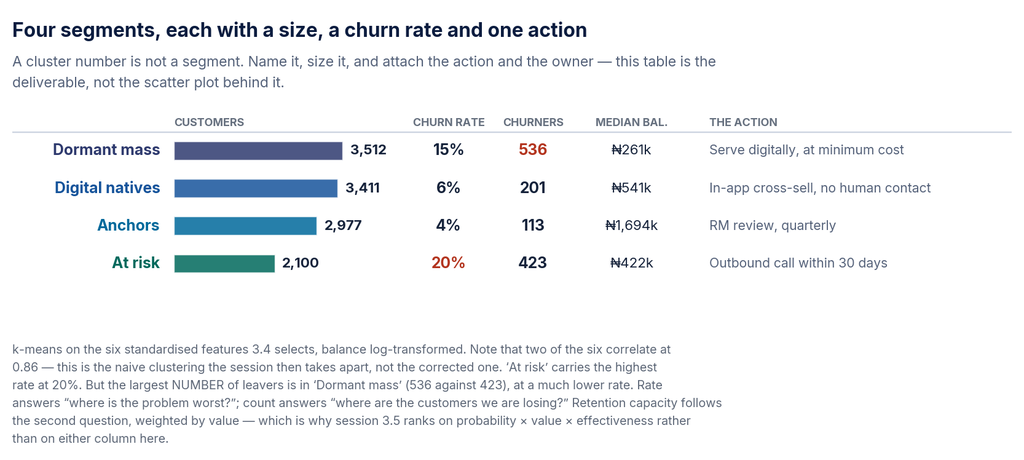

A four-row table of bank segments with a bar for size, then churn rate, churner count, median balance and one action each. The highest churn rate and the highest churner count are in different rows.

## Stability — the question nobody asks

You are going to run a campaign against these segments in three months’ time. **Will the segments still be there?**

The cheapest check: split the base in half at random, cluster each half separately, then score everybody twice — once with each half’s centres — and ask how much the two groupings agree about which customers belong together.

Cluster *numbers* are arbitrary between two fits, so comparing centre tables row by row compares two unrelated orderings. Compare the **partitions**, not the labels.

## Now in your sector · 3.4

Energy & extractives

Segment wells by decline and downtime profile, and gas customers by load profile. Each segment gets a different maintenance or commercial play.

Data: energy_production_daily.csv

Pensions & public sector

Employers: always on time, late but pays, chronic non-remitter. Three segments, three interventions, three costs.

Data: pension_remittances.csv

Financial services

Microfinance borrowers and securities clients, by RFM first.

Data: bank_customers.csv

Commercial & customer

Subscribers, distributors and prospective corporate clients.

Data: fmcg_sell_out.csv

## 3.5 · Propensity and the leak

14:45 — 15:30 · The model that scored 0.98

## What a propensity model is, and what AUC measures

A **propensity model** estimates, for each customer, the probability that something will happen — that they will leave, buy, default or respond. It produces a number between 0 and 1 for every row, and all of its commercial value lies in what you do with the resulting ranking.

**AUC** answers one question. Pick a customer who churned and a customer who did not, entirely at random: how often does the model give the churner the higher score?

0.5 is a coin. 1.0 never gets that comparison wrong. Most production churn models in retail banking live between **0.70 and 0.80**, and a team moving from 0.74 to 0.79 has had a good quarter.

## Build it first. Let it be too good.

```r
rec <- recipe(churned ~ tenure_months + age + products_held + avg_balance_ngn +
                digital_engagement_score + txns_last_90d + complaints_last_12m +
                salary_domiciled + nps_last_survey + segment +
                closure_form_started,          # <- everything available
              data = train)

augment(fit, test) |> roc_auc(churned, .pred_yes)
```

```
#> 0.984
```

**0.984.** Most production churn models in retail banking live between 0.70 and 0.80.

Somebody in the room is now drafting the email.

## Stop. One question, about time.

Would I have known this at the moment I needed to act?

Not *is it correlated* — you hope everything is. Not *is it significant*. At the moment you would score the customer and decide whether to call them, **does this value exist yet, in the system, in the form the model saw it?**

Go down the column list, one at a time. Two minutes.

## Four shapes leakage takes

1. **Post-outcome fields.** Closure forms, exit interviews, cancellation reason codes, write-off flags — populated *because* the outcome happened.
2. **Updated-in-place fields.** A status column that is overwritten each time it changes, so your history contains today’s status rather than the status as at the training date.
3. **Aggregates computed over the whole period**, including the future. An “average spend” that quietly includes the months after the customer left, during which they spent nothing.
4. **An identifier that encodes the answer.** Account numbers issued in blocks, where a prefix happens to correspond to a closure batch.

## The leak announces itself as success

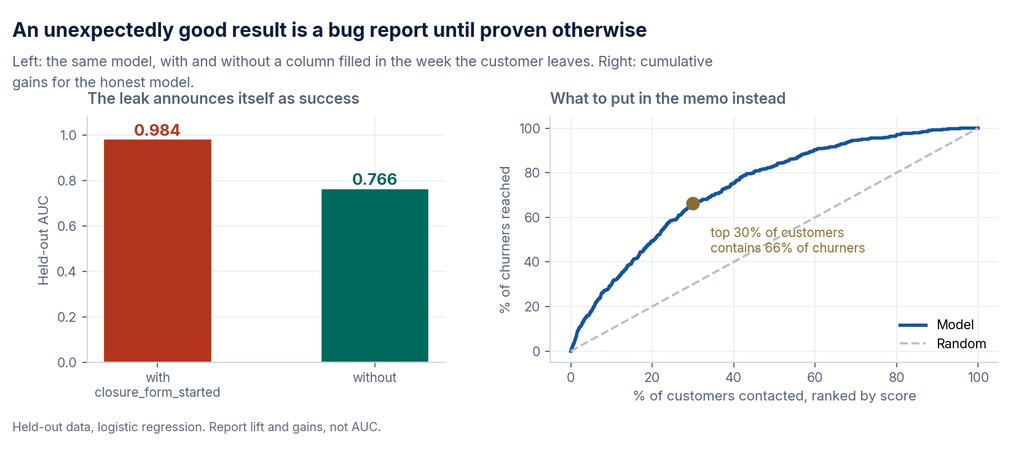

Left: two bars of held-out AUC — 0.984 with the leaking column, 0.766 without it. Right: a cumulative gains curve for the honest model.

## Lift is the number that goes in the memo

AUC is a technical summary and it belongs in the appendix, because nobody in the room can convert it into a decision.

**Lift** can be converted. If the retention team can call 600 customers a month, the question is: *how many more churners do I reach in the top 600 by score than I would by calling 600 at random?*

The **cumulative gains curve** on the previous slide answers the same question cumulatively: working down the ranked list, what share of all the churners have you covered by each point?

*“Calling the top tenth by score finds three times as many at-risk customers as calling a tenth at random.”* That sentence is what goes in the memo, and a reader can act on it without knowing what a model is.

## The threshold is never 0.5

```r
cost_of_call    <- 2500      # ₦, fully loaded
value_of_save   <- 180000    # ₦, annual contribution
prob_call_works <- 0.30      # MEASURE this. Do not assume it.

threshold <- cost_of_call / (value_of_save * prob_call_works)
```

```
#> 0.0463   -> call anyone above a 4.6% churn probability
```

`prob_call_works` is the effectiveness of the intervention, which almost nobody has measured, because the calls were never run against a control group.

**That is Friday.** This is the moment the room realises it is coming.

## Rank by the product, not the probability

Probability of the event × value at stake × probability the intervention works

Most propensity models compute the first term and are then deployed as though they had computed all three.

A customer who is certain to leave and impossible to persuade is not worth calling — and a naive highest-probability-first rule fills your call list with exactly those people, which is one reason retention programmes so often report disappointing results against a model that was working perfectly well.

## The question next door: who is in the file at all?

Leakage is about **time**. Its close relative is about **membership** — which rows made it into the file to begin with.

Open `b2b_funnel.csv`, look at what correlates with a win, and then ask the question that actually settles it:

What had to be true for a row to exist in this file — or for this column to be filled in?

## Now in your sector · 3.5

Energy & extractives

Predicting an off-spec sample or an equipment failure? Ask of every column whether you would have known it the day before. Fields written by the follow-up process are the usual leak.

Data: energy_lab_qc.csv

Pensions & public sector

Predicting a 90-day default? Ask of every column whether it exists before the default. Fields created by the enforcement process are the usual leak in a regulator's data.

Data: pension_remittances.csv

Financial services

Loan default with a 'restructured' flag; churn with closure_form_started.

Data: bank_customers.csv

Commercial & customer

Churn with a port-out request already logged.

Data: bank_customers.csv

## Lab 3 · The forecast market

15:45 — 16:45

One depot per table. History to **30 March 2026**. Q2 is held out — it is not in your folder and not in the repository.

Post **two numbers**: an 80% interval for your depot’s Q2 units, plus one card saying in a single sentence why you widened or narrowed the interval your model produced.

Everybody gets six chips. Bet on any interval, maximum three per entry. A chip inside pays two. **The widest correct interval scores half.**

Then the holdout goes on the projector, depot by depot.

## The debrief is the content

Most people’s 80% intervals contain the truth about **45%** of the time.

Count the hits and write the fraction on the board. Ask the widest-correct and narrowest-correct tables to explain their reasoning. Ask the table that missed by most what they needed to know — it is almost always a *data* answer, not a modelling one.

Then: **where in your organisation does someone commit to a number without an interval, and what happens when they are wrong?**

## Close

Capstone checkpoint: **one chart, one forecast or one segmentation you would defend.**

Before you leave: one failure logbook entry from the leakage session · the number you would submit as a range rather than a point, and who would have to agree to it.

Tomorrow is about everything that is not in a database — and about how the number gets from your script to somebody who can act on it.